# Genetic interactions in Systemic Sclerosis

Anna L Tyler

8/Aug/2018

## Introduction

This purpose of this project is to investigate genetic interactions influencing the presence of autoantibodies as well as lung function in a cohort of patients with systemic sclerosis (SSc). We use the Combines Analysis of Pleiotropy and Epistasis (CAPE) , which increases power to detect interactions by combining information across multiple traits.

We identify three high-confidence candidates that influence lung function in SSc patients.

## CAPE setup

Set up all the libraries and functions we will use

```r
needed.packages <- c("evd", "Matrix", "fdrtool", "shape", "corpcor", "RColorBrewer",
"doParallel","foreach", "caTools", "stringr", "abind", "propagate", "knitr", "pander", "igraph",
"RColorBrewer", "gProfileR", "pheatmap", "here")

for(i in 1:length(needed.packages)){library(needed.packages[i], character.only = TRUE)}
```

Set up directories.

```r
project.dir <- here()
code.dir <- here("code")
data.dir <- here("data")
results.dir <- here("results")
```

Source all the code used

```r
all.code.dir <- list.files(code.dir, full.names = TRUE)
for(i in 1:length(all.code.dir)){
    all.fun <- list.files(all.code.dir[i], pattern = ".R", full.names = TRUE)
    for(i in 1:length(all.fun)){source(all.fun[i])}
    }
```

The following code reads in raw data and builds the cape objects. It is not run here.

```r
build.ssc.cape.data()
```

Instead we will read in the built object carrying the phenotype data,

```r
SScPop <- readRDS(here("data", "project_data", "cross.RData"))
```

and the genotype data. We also converted the genotypes to a dominant coding, which gives us more patients for all marker pair genotypes.

```r
geno <- readRDS(here("data", "project_data", "geno.RData"))
geno[which(geno >= 0.5)] <- 1
```

We used sex as a covariate.

```r
SScPop <- pheno2covar(SScPop, "sex")
```

## Look at trait distributions

We then selected the traits that we are interested in:

```r
SScPop <- select.pheno(SScPop, c("centromere", "nucleolar", "pf1_fvcp", "pf1_dlcp"))
```

We looked at two patterns of autoantibody staining. The first is a centromeric pattern (“centromere”). This pattern is associated with sclerodactyly and Raynaud’s phenomenon as well as other CREST symptomes . The centromeric pattern of autoantibody is also associated with the limited form of SSc, and with patients at lower risk of internal organ involvement . The second autoantibody staining pattern is nucleolar, which is associated with interstitial lung disease and pulmonary hypertension . The distributions among the patients were as follows:

```r
d.t <- table(as.data.frame(SScPop$pheno[,c("centromere", "nucleolar")]))
d.t
```

```
##           nucleolar
## centromere   0   1
##          0 379 189
##          1 252   5
```

```r
aa.mat <- matrix(as.vector(d.t))
aa.mat <- aa.mat/sum(aa.mat)
aa.fig.width = g3.fig.min.width
aa.fig.height <- aa.fig.width/5.5
pdf(here("results", "Figures", "Fig_AA_proportions.pdf"), width = aa.fig.width, height = aa.fig.height)
par(mar = c(1.5,1,1.5,1), ps = 9, mgp = c(3, 0.3, 0))
barplot(aa.mat, col = c("#7fc97f", "#beaed4", "#fdc086", "#386cb0"), horiz = TRUE, axes = FALSE)
axis(1)
par(xpd = TRUE)
y.val = 1.7
text(y = y.val, x = 0.25, labels = "None")
text(y = y.val, x = 0.6, labels = "Centromere")
text(y = y.val, x = 0.89, labels = "Nucleolar")
text(y = y.val, x = 0.99, labels = "Both", srt = 45, adj = 0)
dev.off()
```

We also looked at two lung function tests: forced vital capacity percent predicted: “pf1_fvcp”, and diffusion lung capacity predicted: “pf1_dlcp.” Forced vital capacity is the the volume of air that can be forcibly blown out after a full inspiration. The percent predicted is the percent of the predicted value for a person with similar characteristics, such as height, age, and sex.

Diffusion lung capacity is a measure of the efficiency of gas transfer from the lungs to the blood. As with FVCP, the percentage is based on the percentage of the predicted value for a person with similar characteristics such as height, age, and sex.

Here we look at some properties of the traits.

```r
#assign variable names to all traits for easier use
centromere <- SScPop$pheno[,"centromere"]
centromere[which(centromere == 0)] <- "-"
centromere[which(centromere == "1")] <- "C"

nucleolar <- SScPop$pheno[,"nucleolar"]
nucleolar[which(nucleolar == 0)] <- "-"
nucleolar[which(nucleolar == "1")] <- "N"

sex <- SScPop$p.covar.table[,1]
sex[which(sex == 0)] <- "F"
sex[which(sex == "1")] <- "M"

FVCP <- SScPop$pheno[,"pf1_fvcp"]
DLCP <- SScPop$pheno[,"pf1_dlcp"]
```

Both traits were roughly normally distributed with maximum values ranging to above 100%:

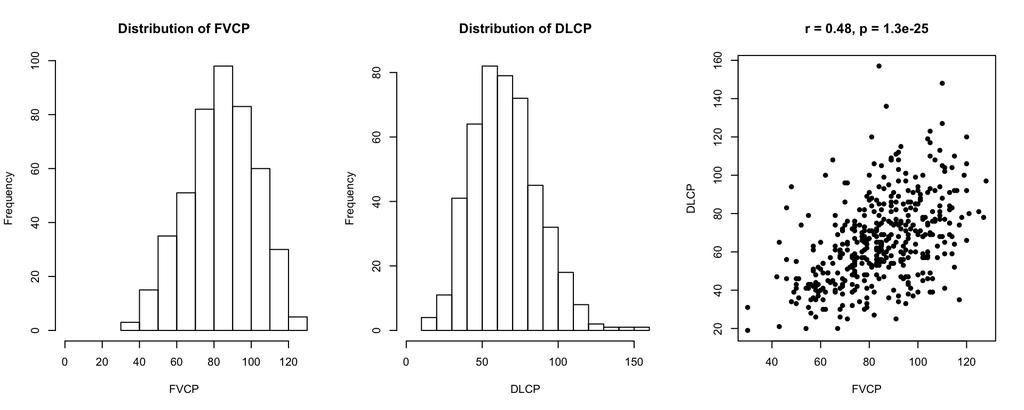

```r
par(mfrow = c(1,3))
hist(FVCP, main = "Distribution of FVCP", xlim = c(0, max(FVCP, na.rm = TRUE)), xlab = "FVCP")
hist(DLCP, main = "Distribution of DLCP", xlim = c(0, max(DLCP, na.rm = TRUE)), xlab = "DLCP")
correlation <- cor.test(FVCP, DLCP)
r <- signif(correlation$estimate, 2)
p <- signif(correlation$p.value, 2)
plot(FVCP, DLCP, pch = 16, main = paste0("r = ", r, ", p = ", p))
```

We normalized the traits for our analysis using a rank Z transform:

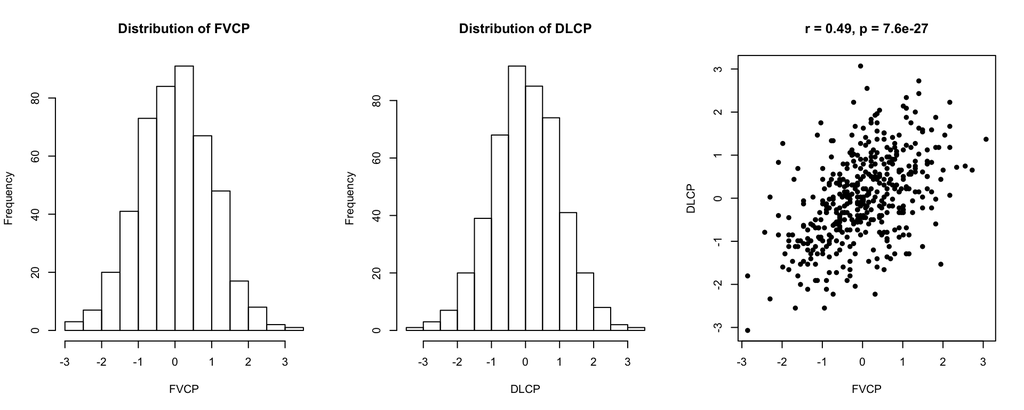

```r
SScPop <- norm.pheno(SScPop)

FVCP <- SScPop$pheno[,"pf1_fvcp"]
DLCP <- SScPop$pheno[,"pf1_dlcp"]

par(mfrow = c(1,3))
hist(FVCP, main = "Distribution of FVCP", xlab = "FVCP")
hist(DLCP, main = "Distribution of DLCP", xlab = "DLCP")
correlation <- cor.test(FVCP, DLCP)
r <- signif(correlation$estimate, 2)
p <- signif(correlation$p.value, 2)
plot(FVCP, DLCP, pch = 16, main = paste0("r = ", r, ", p = ", p))
```

We looked to see if there were any associations between the autoantibody patterns and the lung function tests.

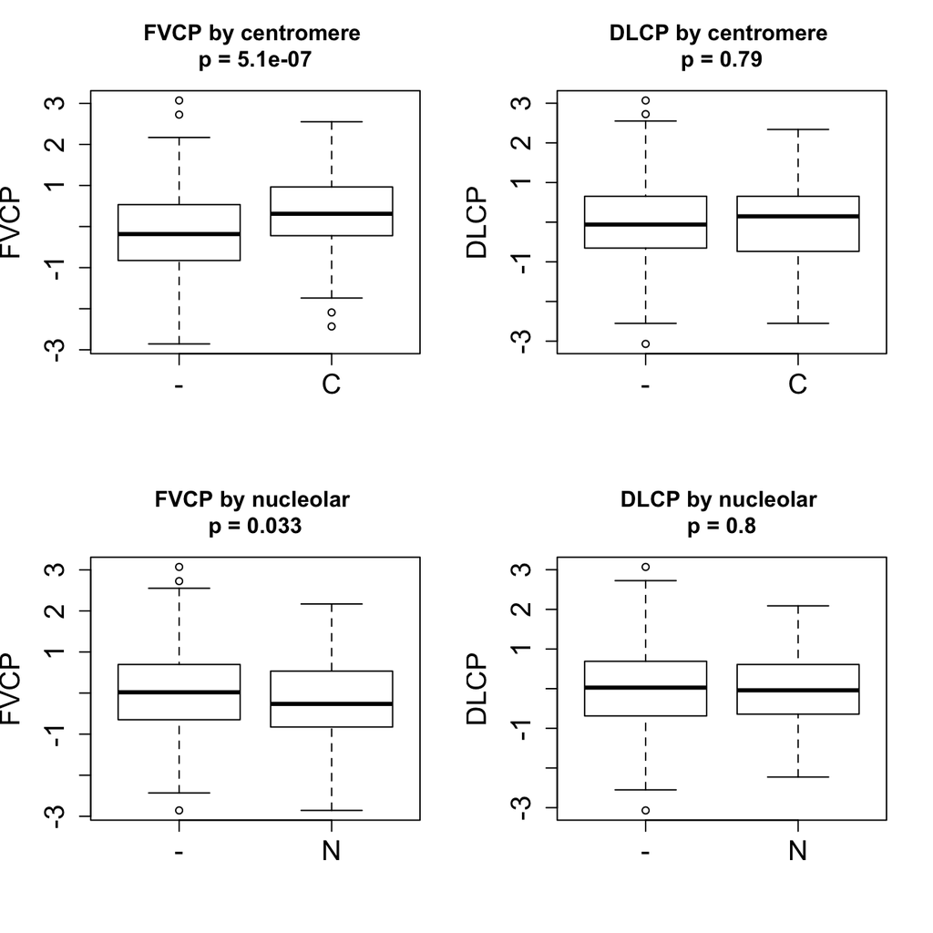

```r
#function to make boxplot and test association
plot.association <- function(aa, lung_trait){
    aa.name <- deparse(substitute(aa))
    trait.name <- deparse(substitute(lung_trait))
    aa <- as.factor(aa)
    test <- t.test(lung_trait~aa)
    pval <- signif(test$p.value, 2)
    boxplot(lung_trait~aa, names = levels(aa), ylab = trait.name,
    main = paste(trait.name, "by", aa.name, "\np =", pval), cex.lab = 1.5, cex.axis = 1.5)
    }

par(mfrow = c(2,2))
plot.association(centromere, FVCP)
plot.association(centromere, DLCP)
plot.association(nucleolar, FVCP)
plot.association(nucleolar, DLCP)
```

The presence of centromeric autoantibody staining has previously been associated with lower risk of internal organ involvement in SSc , while nucleolar autoantibody staining has been associated with increased risk of interstitial lung disease and pulmonary hypertension. In support of these findings, the presence of centromeric autoantibody staining in this population was associated with higher FVCP, while the presence of the nucleolar autoantibody was associated with a slight decrease in FVCP. However, there was no association between either autoantibody and DLCP.

We also looked at the effects of sex:

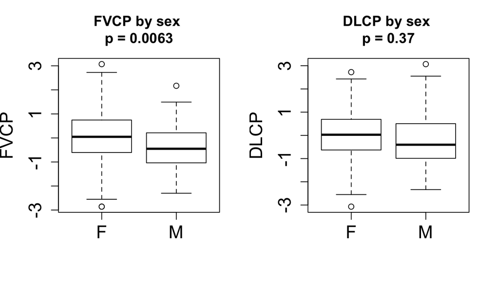

```r
par(mfrow = c(1,2))
plot.association(sex, FVCP)
plot.association(sex, DLCP)
```

Sex had a main effect on FVCP, but no DLCP. Males had a significantly lower FVCP than females.

In addition for main effects, we looked for interaction effects between the autoantibodies, and between the autoantibodies and sex.

```r
factor.interaction <- function(trait, factor1, factor2, plot.type = c("box", "line")){
    plot.type = plot.type[1]
    f1.name <- deparse(substitute(factor1))
    f2.name <- deparse(substitute(factor2))
    trait.name <- deparse(substitute(trait))
    if(plot.type == "box"){
        test <- anova(aov(trait~as.factor(factor1)*as.factor(factor2)))
        pval <- signif(test$"Pr(>F)"[3], 2)
        stats <- boxplot(trait~as.factor(factor1)*as.factor(factor2), ylab = trait.name,
        main = paste(trait.name, "by", f1.name, "and", f2.name, "\np =", pval), cex.lab = 1.5, cex.axis = 1.5)
        par(xpd = TRUE)
        text(x = 1:4, y = min(trait, na.rm = TRUE)*1.45, labels = stats$n)
        par(xpd = FALSE)
        }else{
        test <- lm(trait~as.factor(factor1)*as.factor(factor2))
        results <- summary(test)$coefficients
        pval <- signif(results[nrow(results),ncol(results)], 2)
        no.na <- which(!is.na(trait))
        interaction.plot(factor1[no.na], factor2[no.na], trait[no.na], xlab = f1.name, ylab = trait.name, trace.label = f2.name, main = paste("p =", pval))
        }
    }
```

A plot of both autoantibodies together shows that there is no interaction between the effects of the autoantibodies, although, patients with only the centromere autoantibody trend toward the highest lung function.

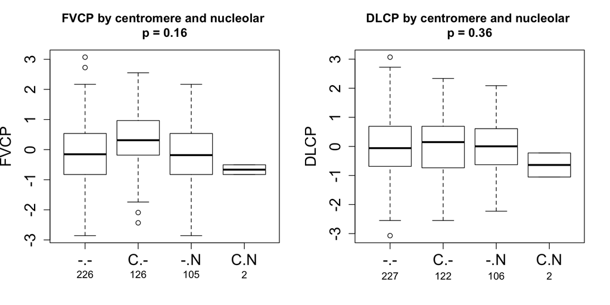

```r
par(mfrow = c(1,2))
factor.interaction(FVCP, centromere, nucleolar)
factor.interaction(DLCP, centromere, nucleolar)
```

There is an interaction between sex and the nucleolar autoantibody. While patients positive for the nucleolar autoantibody tend to have a slightly lower FVCP on average, this effect is driven primarily by the female patients. Male patients with the nucleolar autoantibody tend to have slightly higher FVCP than males without the nucleolar autoantibody.

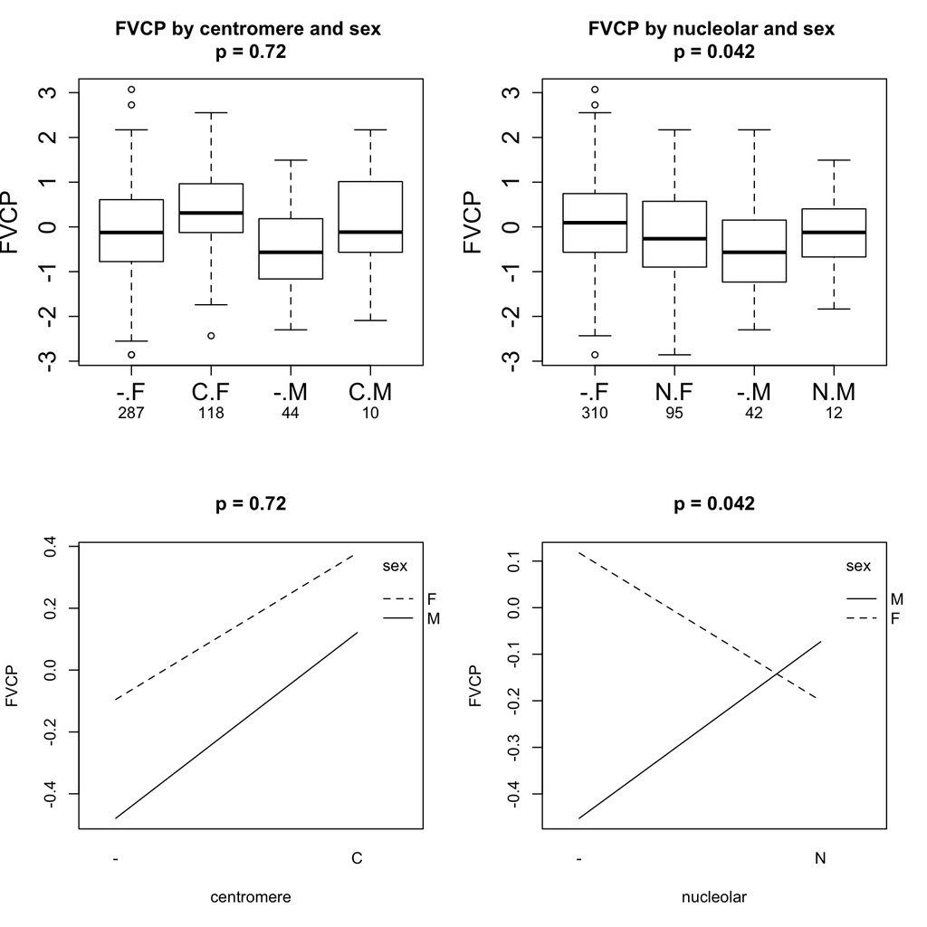

```r
par(mfrow = c(2,2))
factor.interaction(FVCP, centromere, sex)
factor.interaction(FVCP, nucleolar, sex)
factor.interaction(FVCP, centromere, sex, "line")
factor.interaction(FVCP, nucleolar, sex, "line")
```

There was no interaction between sex and the autoantibodies affecting DLCP, although males positive for each autoantibody trended toward higher DLCP. DLCP in females was largely unaffected by the presence of the autoantibodies.

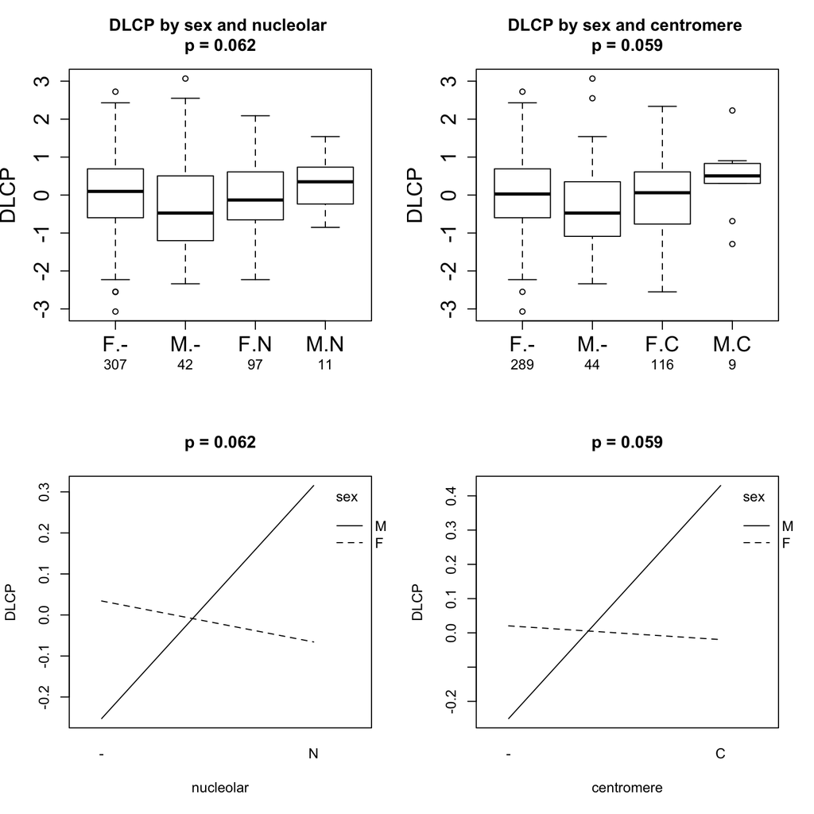

```r
par(mfrow = c(2,2))
factor.interaction(DLCP, sex, nucleolar)
factor.interaction(DLCP, sex, centromere)
factor.interaction(DLCP, nucleolar, sex, "line")
factor.interaction(DLCP, centromere, sex, "line")
```

```r
int.lines <- function(y,x,split.by, lwd = 3, sig = FALSE, errors = TRUE, yaxis = TRUE, names.cex = 1){
    split.levels <- levels(as.factor(split.by))
    x.levels <- levels(as.factor(x))
    se.mat <- mean.mat <- matrix(NA, nrow = length(split.levels), ncol = length(x.levels))
    rownames(mean.mat) <- rownames(se.mat) <- split.levels
    colnames(mean.mat) <- colnames(se.mat) <- x.levels
    for(i in 1:length(split.levels)){
        for(j in 1:length(x.levels)){
        idx <- intersect(which(x == x.levels[j]), which(split.by == split.levels[i]))
        mean.mat[i,j] <- mean(y[idx], na.rm = TRUE)
        se.mat[i,j] <- sd(y[idx], na.rm = TRUE)/sqrt(length(idx))
        }
    }
    if(errors){
        ymin <- min(mean.mat-se.mat);ymax <- max(mean.mat+se.mat)
    }else{
        ymin <- min(mean.mat);ymax <- max(mean.mat)
    }

    plot.height = ymax - ymin
    plot.new()
    plot.window(xlim = c(0.5, ncol(mean.mat)+0.5), ylim = c(ymin-(plot.height*0.05), ymax+(plot.height*0.05)))
    for(i in 1:nrow(mean.mat)){
        points(x = 1:ncol(mean.mat), y = mean.mat[i,], lty = i, type = "l", lwd = lwd)
        if(errors){
        segments(x0 = 1:ncol(mean.mat), y0 = c(mean.mat[i,]+se.mat[i,]), y1 = c(mean.mat[i,]-se.mat[i,]), lwd = lwd)
        }
    }
    par(xpd = TRUE)
    for(i in 1:ncol(mean.mat)){
        if(colnames(mean.mat)[i] == "-"){
            text(x = i, y = (ymin-(plot.height*0.1)), labels = expression(symbol("\306")), cex = names.cex)
        }else{
            text(x = i, y = (ymin-(plot.height*0.1)), labels = colnames(mean.mat)[i], cex = names.cex)
        }
    }
    if(yaxis){axis(2, cex.axis = cex.lab)}
    #text(x = 0, y = mean(c(ymin, ymax)), labels = deparse(substitute(y)), cex = cex.lab, srt = 90)
    if(sig){text(x = 1.5, y = ymax, labels = "*", cex = cex.lab*1.5)}
}

make.legend <- function(split.by, cex = 2, lwd = 2, x = 0.2, y = 0.9){
    plot.new()
    plot.window(xlim = c(0,1), ylim = c(0,1))
    split.levels <- levels(as.factor(split.by))
    split.levels[which(split.levels == "-")] <- expression(symbol("\306"))
    legend(x,y,lty = 1:length(split.levels), legend = split.levels, cex = cex, lwd = lwd, horiz = TRUE, bty = "n")
    # draw.rectangle(0,1,0,1)
}


pdf(here("results", "Figures", "Fig_Lung_Interactions_All.pdf"), width = 10, height = 6)
layout.mat <- matrix(c(0, 1:3, 0, 4:14), nrow = 4, byrow = TRUE)
layout(layout.mat, widths = c(0.2, rep(1, 3)), heights = c(0.3, 0.3, rep(1, 3)))

par(mar = c(1, 1, 1, 1))
plot.text("Centromere by Nucleolar", cex = cex.lab)
plot.text("Centromere by Sex", cex = cex.lab)
plot.text("Nucleolar by Sex", cex = cex.lab)

par(mar = c(0, 0, 0, 0))
make.legend(nucleolar, lwd = 1.5, cex = 1.5)
make.legend(sex, lwd = 1.5, cex = 1.5)
make.legend(sex, lwd = 1.5, cex = 1.5)

plot.text("FVCP", srt = 90, cex = cex.lab)
par(mar = c(2,3,0,0))
int.lines(FVCP, centromere, nucleolar, sig = FALSE, errors = TRUE)
int.lines(FVCP, centromere, sex, sig = FALSE, errors = TRUE, yaxis = FALSE)
int.lines(FVCP, nucleolar, sex, sig = TRUE, errors = TRUE, yaxis = FALSE)

par(mar = c(1, 1, 1, 1))
plot.text("DLCP", srt = 90, cex = cex.lab)
par(mar = c(2,3,0,0))
int.lines(DLCP, centromere, nucleolar, sig = FALSE)
int.lines(DLCP, centromere, sex, sig = FALSE)
int.lines(DLCP, nucleolar, sex, sig = FALSE)
dev.off()
```

```r
#also plot just the significant and almost significant interactions
fig.int.height <- g3.fig.min.width
fig.int.width <- fig.int.height*0.45
pdf(here("results", "Figures", "Fig_Lung_Trait_Interactions_Sig.pdf"), width = fig.int.height, height = fig.int.width)
# quartz(width = fig.int.height, height = fig.int.width)
layout.mat <- matrix(c(1:6), nrow = 2, byrow = TRUE)
layout(layout.mat, widths = c(1,1), heights = c(0.3, 1))
# layout.show(9)
legend.cex <- 1;legend.lwd = 1
par(mar = c(0, 0, 0, 0), ps = 9)
legend.x <- 0.25;legend.y <- 0.8
make.legend(sex, lwd = legend.lwd, cex = legend.cex, x = legend.x, y = legend.y)
make.legend(sex, lwd = legend.lwd, cex = legend.cex, x = legend.x, y = legend.y)
make.legend(sex, lwd = legend.lwd, cex = legend.cex, x = legend.x, y = legend.y)

par(mar = c(4,3,0,0));ylab.line = 1.8; xlab.line = 1.3
int.lines(FVCP, nucleolar, sex, sig = TRUE, errors = TRUE, yaxis = TRUE, lwd = 1, names.cex = 1.5)
mtext(side = 2, "FVCP", line = ylab.line);mtext(side = 1, "Nucleolar", line = xlab.line)
int.lines(DLCP, centromere, sex, sig = FALSE, lwd = 1, names.cex = 1.5)
mtext(side = 2, "DLCP", line = ylab.line);mtext(side = 1, "Centromere", line = xlab.line)
int.lines(DLCP, nucleolar, sex, sig = FALSE, lwd = 1, names.cex = 1.5)
mtext(side = 2, "DLCP", line = ylab.line);mtext(side = 1, "Nucleolar", line = xlab.line)
dev.off()
```

## Filter SNPs

The next function runs MatrixEpistasis and asks for pairs with p values below a given cutoff. It saves the results for each phenotype. After running MatrixEpistasis, it goes through the phenotype pairs and gets the unique SNPs from the most significant pairs across all traits. This function takes a long time to run, so I am not running it here.

The parameter to note is the p value. I used a cutoff of p = 1e-6, so MatrixEpistasis will only return pairs that have that p value or less.

```r
selected.SNPs <- filterSNPs(SScPop, geno, target.markers = 1500, ref.allele = "A",
pval = 1e-6, chunk.size = 5000, n.cores = 4)
```

This function saves a file for each phenotype that includes the top SNP pairs for each phenotype based on the p value threshold. By running filterSNPs again, but skipping the MatrixEpistasis step, we can take a closer look at these pairs. For example, we can see which epistatic pairs are also pleiotropic, meaning they influence more than one phenotype.

```r
filterSNPs(SScPop, geno, run.matrixEpistasis = FALSE, target.markers = 1500)
```

There isn’t much overlap among the traits. There are 52 pairs shared between the two lung phenotypes. filterSNPs keeps all SNPs in these pairs that are both epistatic and pleiotropic. Then it moves on to the single-marker stats. Single markers can influence multiple traits when paired with other markers. Even it the marker pair is different, individual markers might epistatically influence multiple traits. flterSNPs finds the SNPs that are the most pleiotropic in the following way:

While we have not reached our target number of markers: Start at N = the number of traits tested.

1. Find all SNPs that influence N traits.
2. If we can add all of these SNPs to our list, add them.
3. If this will make the list too big, sort the SNPs by their representation in the traits. For example, a SNP that influenced one trait in twelve pairs will be prioritized over a SNP that influenced one trait in five pairs.
4. Add SNPs in order of their influence until we have reached the target number of markers.

We then run cape using this list of filtered SNPs and the following parameters:

```r
param.file <- here("results", "cape.parameters.txt")
param.table <- readParameters(param.file)
kable(param.table[which(!is.na(param.table[,1])),])
```

|  | x |
| --- | --- |
| traits | centromere nucleolar pf1_fvcp pf1_dlcp |
| covariates | sex |
| traits.scaled | TRUE |
| traits.normalized | TRUE |
| scan.what | Eigentraits |
| eig.which | 1 2 |
| pval.correction | fdr |
| ref.allele | A |
| singlescan.perm | 0 |
| marker.selection.method | from.list |
| SNPfile | filteredSNPs.txt |
| max.pair.cor | 0.5 |
| pairscan.null.size | 1500000 |

Before we run cape, we also want to check for population structure to decide whether we should do a correction for population structure. To test for structure, we performed single marker regression at each marker to look for associations with each trait. Under the null hypothesis, p values are uniformly distributed. If there is population structure influencing the results, we expect to see a substantial deviation from this distribution creating inflated significance for a substantial number of markers. On the other hand, if the p value distributions are largely uniform with a few markers deviating from this distribution, there is no population structure to correct for.

```r
#need to debug this


regression.file <- here("results", "single.regression.RData")
sub.geno <- get.geno(SScPop, geno)
geno.mat <- sub.geno[,2,]

if(!file.exists(regression.file)){
    get.lin.p <- function(y,x){
        num.y <- length(unique(y[which(!is.na(y))]))
        if(num.y == 2){fam = "binomial"}
        if(num.y > 2){fam = "gaussian"}
        y <- y - min(y)
        y <- y/max(y)
        model <- glm(y~x, family = fam)
        modelc <- coefficients(summary(model))
        p <- modelc[nrow(modelc), ncol(modelc)]
        return(p)
    }

    all.p <- matrix(NA, ncol = ncol(SScPop$pheno), nrow = ncol(geno.mat))
    colnames(all.p) <- colnames(SScPop$pheno)
    for(i in 1:ncol(SScPop$pheno)){
        cat(i, "\n")
        pvals <- apply(geno.mat, 2, function(x) get.lin.p(SScPop$pheno[,i], x))
        all.p[,i] <- pvals
    }

    save(all.p, file = regression.file)
}else{
    all.p <- readRDS(regression.file)
}

par(mfrow = c(2,2))
for(i in 1:ncol(all.p)){
    qqnorm(qnorm(all.p[,i]), main = colnames(test.pop$pheno)[i])
    qqline(qnorm(all.p[,i]))
}
```

[output not shown]

Here we are running CAPE with two of four eigentraits. These eigentraits contrast the two lung function tests with each of the autoantibodies in turn.

```r
eig.pop <- get.eigentraits(SScPop)
```

```
## Removing 417 individuals with missing phenotypes.
```

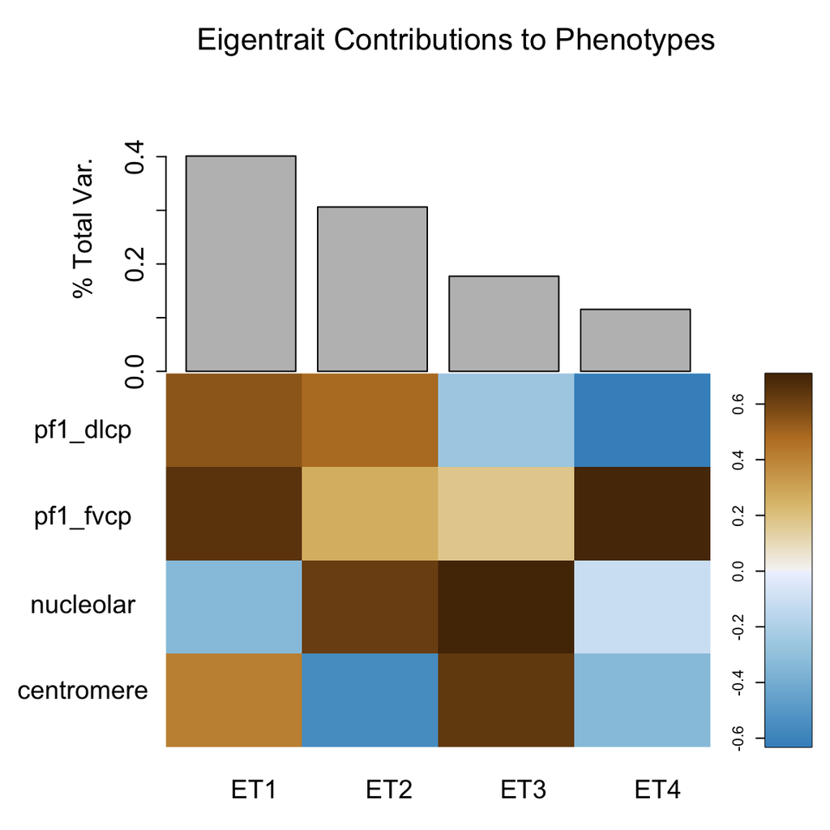

```r
var.accounted <- plotSVD(eig.pop)
```

```r
system(paste("cp filteredSNPs.txt", results.dir))
final.pop <- run.cape(SScPop, geno)
```

```r
pop.data <- here("results", "cross.RData")
SScPop <- readRDS(pop.data)
```

These SNPs filtered for both pleiotropy and epistasis formed a CAPE network.

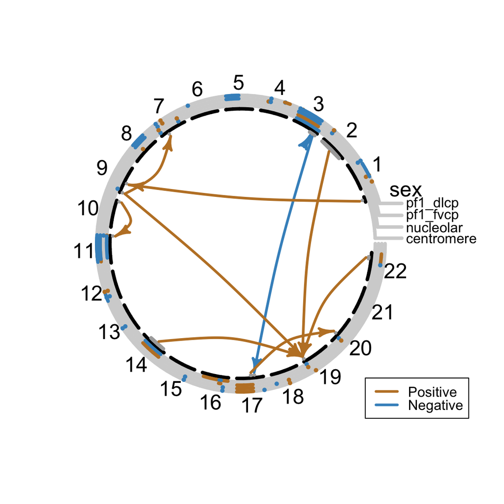

```r
plotNetworkDO(SScPop, show.alleles = FALSE)
```

The table of significant SNP interactions is as follows:

```r
var.inf <- writeVariantInfluences(SScPop, include.main.effects = FALSE, write.file = FALSE)
knitr::kable(as.data.frame(var.inf[,c(1,2,4,5,10,14)]))
```

| Source | Chr | Target | Chr | Effect | p.adjusted |
| --- | --- | --- | --- | --- | --- |
| rs1449292_B | 3 | rs792399_B | 17 | -1.00948265115757 | 0 |
| rs1449292_B | 3 | rs556874_B | 3 | -0.869869093605696 | 0 |
| rs2055566_B | 2 | rs3746070_B | 19 | 0.818228099493505 | 0 |
| rs6574751_B | 14 | rs3746070_B | 19 | 0.770632024760673 | 0 |
| rs7033108_B | 9 | rs6466555_B | 7 | 1.15341633886639 | 0 |
| rs7033108_B | 9 | rs10245192_B | 7 | 1.15341633886639 | 0 |
| rs2065936_B | 10 | rs2734510_B | 11 | 1.29903849272547 | 0 |
| rs17694404_B | 17 | rs6105966_B | 20 | 1.24791388253724 | 0 |
| sex | 0 | rs7854383_B | 9 | 1.41845393260669 | 0 |
| rs7033108_B | 9 | rs3746070_B | 19 | 0.806855601041902 | 0 |
| rs9607931_B | 22 | rs3746070_B | 19 | 0.815874044242893 | 0 |

We used [SNPNexus](http://www.snp-nexus.org) to learn more about the individual SNPs. In particular we identified the nearest (or overlapping) gene for each SNP. We assigned each SNP to its nearest gene. The nodes are labeled with the gene nearest to the SNP. Node color indicates whether the SNP overlaps the gene, is upstream, or downstream, and node shape indicates whether the gene is protein coding, or another type of gene. Edge color indicates positive (enhancing) and negative (suppressing) interactions.

```r
snp.file <- here("data", "ncsnp_11708.txt")
snp.gene.table <- as.matrix(read.table(snp.file, sep = "\t", stringsAsFactors = FALSE, header = TRUE))
snp.net <- SNPNexus.to.gene.net(SScPop, snp.gene.table, vertex.size = 40, label.x.shift = 0.3,
label.y.shift = 0.1)
```

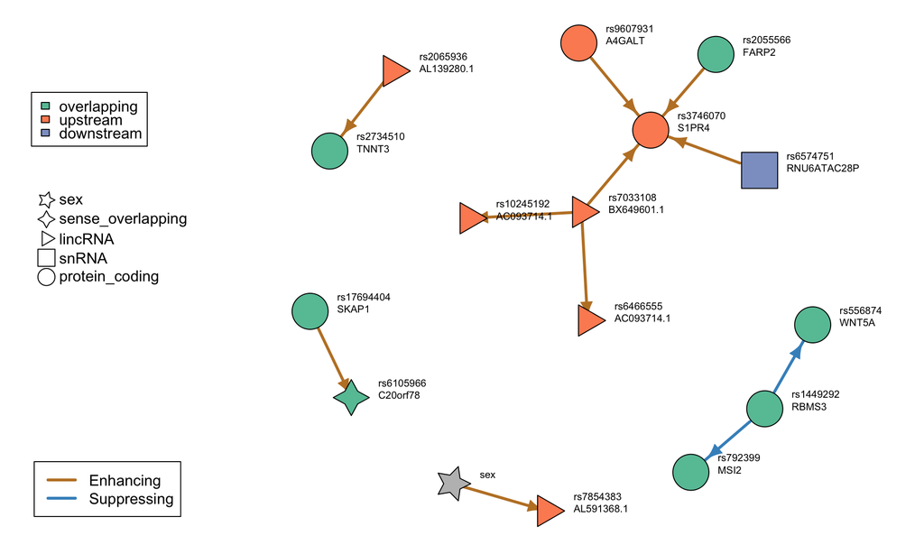

The two most significant interactions are suppressing and create a three-node subnetwork between three SNPs that overlap protein coding genes: WNT5A, RBMS3, and MSI2. WNT signaling is known to be involved in SSc, and for the remainder of this study, we focus on this top subnetwork.

```r
top.ints <- var.inf[1:2, c("Source", "Target")]
top.int.genes <- top.ints #replace the SNP names with gene names
top.int.genes[,1] <- snp.gene.table[match(gsub("_B", "", top.ints[,1]), snp.gene.table[,2]), 5]
top.int.genes[,2] <- snp.gene.table[match(gsub("_B", "", top.ints[,2]), snp.gene.table[,2]), 5]
```

The SNPs interacting in this network are the following:

```r
top.snps <- unique(as.vector(top.ints))
cat(top.snps, sep = "\t")
```

```
## rs1449292_B  rs792399_B  rs556874_B
```

```r
top.genes <- unique(as.vector(top.int.genes))
cat(top.genes, sep = "\t")
```

```
## RBMS3    MSI2    WNT5A
```

## Gene Expression

We used the “Analyze with GEO2R” button on the GEO website to get the data downloaded and normalized properly. Then we added custom code to look for expression differences in individual genes.

The following functions download the GEO data set, normalize it, and write out the expression data as well as a gene ID table in /Users/atyler/Documents/Projects/Scleroderma/paper/data

They then read in the expression data and plot expression differences in the genes identified in the epistatic network.

We first looked at expression in the lung:

```r
dataset <- "GSE76808" #Association of Interferon- and Transforming Growth Factor-Regulated
                      #Genes and Macrophage Activation With Systemic Sclerosis-Related
                      #Progressive Lung Fibrosis
```

```r
geo.fun <- match.fun(paste0("Download_SSc_", dataset))
geo.fun(path = data.dir)
```

The expression values are normalized by patient, and there do not appear to be any batch effects in these data.

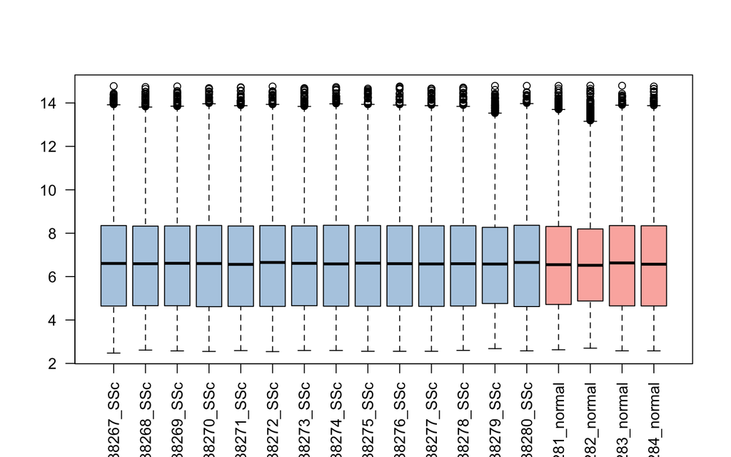

```r
expr <- read.table(here("data", paste0("Expression_Table_", dataset, ".txt")), stringsAsFactors = FALSE, sep = "\t", header = TRUE)
gene.id.table <- read.table(here("data", paste0("Top_table_", dataset, ".txt")), stringsAsFactors = FALSE, sep = "\t", header = TRUE)
pt.class <- sapply(strsplit(colnames(expr), "_"), function(x) x[2])
pt.cols <- brewer.pal(8, "Pastel1")
pt.col <- rep(pt.cols[1], length(pt.class))
pt.col[which(pt.class == "SSc")] <- pt.cols[2]
boxplot(expr, col = pt.col, las = 2)
```

```r
deg.expr <- DEG.in.GEO(top.genes, gene.id.table, expr, return.data = "all")
```

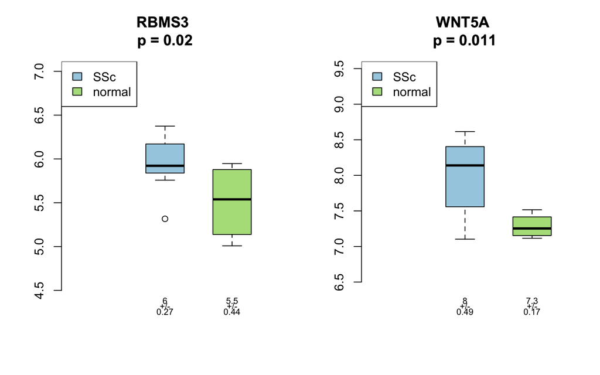

```r
fig.width = g3.fig.min.width
fig.height = g3.fig.min.width/2
pdf(here("results", "Figures", "Fig_DEG.pdf"), width = fig.width, height = fig.height)
par(mfrow = c(1,2), mar = c(1,3,2,0))
for(i in 1:length(deg.expr)){
    if(!is.null(deg.expr[[i]])){
        gene.expr <- deg.expr[[i]][[1]]
        ymax <- max(unlist(gene.expr), na.rm = TRUE)
        ymin <- min(unlist(gene.expr), na.rm = TRUE)
        plot.height <- ymax - ymin
        boxplot(gene.expr, axes = FALSE, main = names(deg.expr)[i], cex = 0.7, cex.main = 0.9)
        axis(2, at = signif(segment.region(ymin, ymax, 4, "ends"), 2))
        par(xpd = TRUE)
        text(x = c(1,2), y = (ymin - (plot.height*0.1)), labels = names(gene.expr))
        if(i == 1){
            mtext("Expression (A.U.)", side = 2, line = 2)
        }
        par(xpd = FALSE)
        stripchart(gene.expr, vertical = TRUE, pch = 16, add = TRUE)
    }
}
dev.off()
```

Both WNT5A and RBMS3 were upregulated in SSc lung samples. MSI2 was not present in this data set.

## Gene coexpression

```r
#set up objects to hold the gprofiler for both pairs
#name them by the interaction pair
pair.sig.enrichments <- vector(mode = "list", length = nrow(top.int.genes))
names(pair.sig.enrichments) <- apply(top.int.genes, 1, function(x) paste0(x, collapse = "_"))
for(gp in 1:nrow(top.int.genes)){
    pair.dir <- here("data", "SEEK", names(pair.sig.enrichments)[gp])
    pair.sig.enrichments[[gp]] <- SEEK.enrichment(top.int.genes[gp,], pair.dir, pval = 0.05)
    }
```

We plotted the $-log_{10}$ of the p value of the enrichments for all data sets for each pair. We highlighted terms that are relevant to SSc. We selected the following terms:

```r
highlight.terms <- c("collagen", "matrix", "fibroblast", "growth factor", "vascular", "vaso", "wound", "wnt")
```

Supplemental_Figure_SEEK_enrichment.pdf shows the $-log_{10}$ of the p value for each term in each subset of data sets. Terms containing strings matching the strings above are colored blue.

```r
pdf(here("results", "Figures", "Supplemental_Figure_SEEK_enrichment.pdf"), width = 11, height = 8)
for(gp in 1:length(pair.sig.enrichments)){
    all.enrich.sig <- pair.sig.enrichments[[gp]]
    for(i in 1:length(all.enrich.sig)){
        all.enrich.sig[[i]] <- plot.enrichment.vis(all.enrich.sig[[i]],
        num.terms = nrow(all.enrich.sig[[i]]), plot.label =
        paste("Enrichment of Genes Significantly Correlated with\n", names(pair.sig.enrichments)[gp],
        "in", names(all.enrich.sig)[i]),
        highlight.terms = highlight.terms)
        pair.sig.enrichments[[gp]] <- all.enrich.sig
        }
    }
dev.off()
```

For easier visualization, we can combine the results into a single matrix showing the $-log_{10}$ p values for all terms. We collected all terms that were relevant to SSc across the data sets and plotted them against each other in a single matrix.

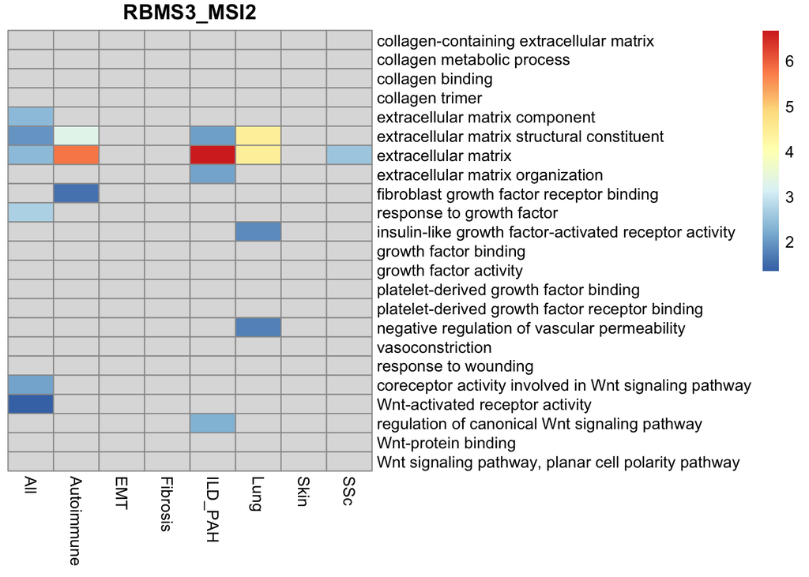

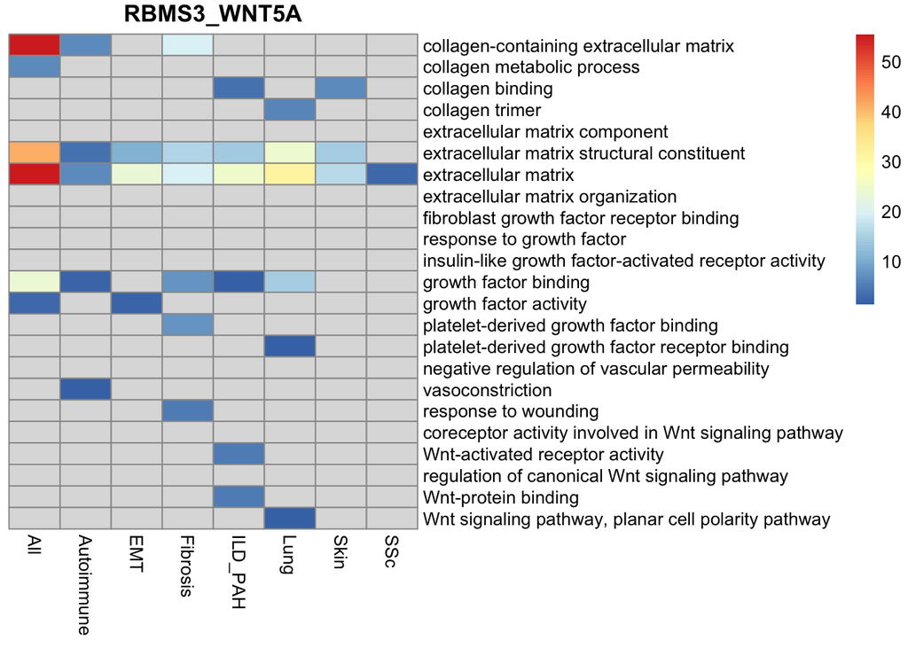

```r
sig.mats <- plot.all.SEEK.terms(pair.sig.enrichments)
```

## Clinical significance

The top two SNP interactions affect the traits in the following way:

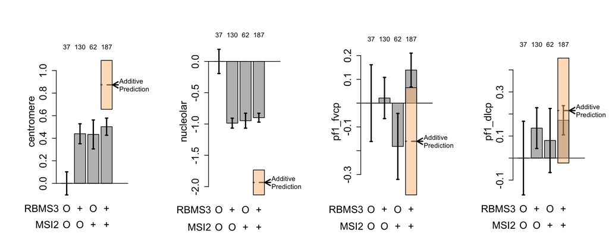

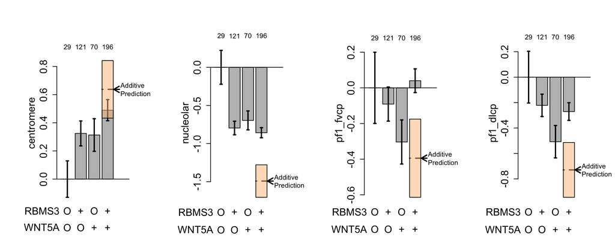

```r
par(mar = c(6,7,6,3))
for(i in 1:nrow(top.ints)){
    plot.effects(SScPop, top.ints[i,1], top.ints[i,2], plot.type = "b",
    error.bars = "se", marker1.label = top.int.genes[i,1],
    marker2.label = top.int.genes[i,2], genotype.labels = c("O", "+"))
    }
```

```r
#plot effects as figures as well
fig.width = g3.fig.max.width
fig.height <- fig.width/4
for(i in 1:nrow(top.ints)){
    pdf(here("results", "Figures", paste0("Fig_Effects", i, ".pdf")),
    width = fig.width, height = fig.height)
    par(mar = c(3,5,2,3))
    plot.effects(SScPop, top.ints[i,1], top.ints[i,2], plot.type = "b",
    error.bars = "se", marker1.label = top.int.genes[i,1],
    marker2.label = top.int.genes[i,2], pheno.labels = c("ACA", "ANA", "FVCP", "DLCP"),
    genotype.labels = c("O", "+"), cex.axis = 1.2, cex.text = 1.2)
    dev.off()
    }
```

## The WNT5A subnetwork

*rs1449292* is located in intron 8 of 13 of RBMS3. It is located in a human QTL for RA (RA3) (Jawaheer et al. 2001) as well as two allergic atopic asthma related QTLs (AASTH43 and AASTH44) (Ober et al. 1998). RBMS3 encodes an RNA-binding protein that belongs to the c-myc gene single-strand binding protein family. This family of genes is involved in wide-ranging processes. [RBSM3](https://www.ncbi.nlm.nih.gov/gene/27303) itself is expressed in skin and highly expressed in lung. It has been shown to inhibit the proliferation and metastasis of breast cancer cells through inactivation of the Wnt/beta-catening signaling pathway (Y. Yang, Quan, and Ling 2018) as well as to inhibit EMT and invation in gastric cells by inhibiting canonical Wnt signaling . It also inhibits microvessel formation through downregulation of MMP2 and beta-catenin (J. Chen et al. 2012). SNPs in RBMS3 were identified as novel risk factors for Sjogren’s syndrome in Chinese women (Song et al. 2016). This gene was isolated by virtue of its binding to an upstream element of the alpha2(I) collagen promoter (Penkov et al. 2000). RBMS3 may also indirectly influence collagen synthesis through controling expression of Px1 (Fritz and Stefanovic 2007).

*rs792399* is located in intron 5 of 13 of the gene MSI2. It is located in COPD QTL 12 (Palmer et al. 2003) and RA QTL 26 (Jawaheer et al. 2001). MSI2 encodes another RNA-binding protein in the Musashi protein family. It has mostly been studied in the context of cancer and has been implicated in EMT . It is upregulated in metastitic-competent lung cancer cell lines and upregulation was associated with aggressively metastatic tumors in patient biopsies . Depletion of MSI2 was associated with reduced invasion and metastatic potential and induced expression of genes associated with epithelial identity, and downregulated genes associated with EMT, such as TGF-beta . MSI2 may influence hepatitis B virus related hepatocellular carcinoma outcomes by dysregulating Wnt signaling .

There is a clear relationship between WNT5A and RBMS3 and SSc, and there is a clear relationship between the two genes, as RBMS3 is known to regulate WNT signaling.

We hypothesize that these three genes interact in SSc to influence both autoantibody status and lung function.

## References

Chen, Juan, Dora Lai-Wan Kwong, Cai-Lei Zhu, Lei-Lei Chen, Sui-Sui Dong, Li-Yi Zhang, Jun Tian, et al. 2012. “RBMS3 at 3p24 Inhibits Nasopharyngeal Carcinoma Development via Inhibiting Cell Proliferation, Angiogenesis, and Inducing Apoptosis.” *PloS One* 7 (9). Public Library of Science: e44636.

Fritz, Dillon, and Branko Stefanovic. 2007. “RNA-Binding Protein RBMS3 Is Expressed in Activated Hepatic Stellate Cells and Liver Fibrosis and Increases Expression of Transcription Factor Prx1.” *Journal of Molecular Biology* 371 (3). Elsevier: 585–95.

Jawaheer, Damini, Michael F Seldin, Christopher I Amos, Wei V Chen, Russell Shigeta, Joanita Monteiro, Marlene Kern, et al. 2001. “A Genomewide Screen in Multiplex Rheumatoid Arthritis Families Suggests Genetic Overlap with Other Autoimmune Diseases.” *The American Journal of Human Genetics* 68 (4). Elsevier: 927–36.

Ober, Carole, Nancy J Cox, Mark Abney, Anna Di Rienzo, Eric S Lander, Benjarat Changyaleket, Heidi Gidley, et al. 1998. “Genome-Wide Search for Asthma Susceptibility Loci in a Founder Population.” *Human Molecular Genetics* 7 (9). Oxford University Press: 1393–8.

Palmer, Lyle J, Juan C Celedón, Harold A Chapman, Frank E Speizer, Scott T Weiss, and Edwin K Silverman. 2003. “Genome-Wide Linkage Analysis of Bronchodilator Responsiveness and Post-Bronchodilator Spirometric Phenotypes in Chronic Obstructive Pulmonary Disease.” *Human Molecular Genetics* 12 (10). Oxford University Press: 1199–1210.

Penkov, Dmitri, Rujing Ni, Cindy Else, Serafin Piñol-Roma, Francesco Ramirez, and Shizuko Tanaka. 2000. “Cloning of a Human Gene Closely Related to the Genes Coding for the c-Myc Single-Strand Binding Proteins.” *Gene* 243 (1). Elsevier: 27–36.

Shi, Ya-Ning, Neng Zhu, Chan Liu, Hong-Tao Wu, Yu Gui, Duan-Fang Liao, and Li Qin. 2017. “Wnt5a and Its Signaling Pathway in Angiogenesis.” *Clinica Chimica Acta* 471. Elsevier: 263–69.

Song, I-Wen, Hsiang-Cheng Chen, Yuh-Feng Lin, Jenn-Hwai Yang, Chi-Ching Chang, Chung-Tei Chou, Ming-Ta Michael Lee, et al. 2016. “Identification of Susceptibility Gene Associated with Female Primary Sjögren’s Syndrome in Han Chinese by Genome-Wide Association Study.” *Human Genetics* 135 (11). Springer: 1287–94.

Wang, Biao, Zhen Tang, Huiyuan Gong, Li Zhu, and Xuegang Liu. 2017. “Wnt5a Promotes Epithelial-to-Mesenchymal Transition and Metastasis in Non-Small Cell Lung Cancer.” *Bioscience Reports*. Portland Press Limited, BSR20171092.

Wang, Wenming, Xiaoling Yu, Chao Wu, and Hongzhong Jin. 2018. “Differential Effects of Wnt5a on the Proliferation, Differentiation and Inflammatory Response of Keratinocytes.” *Molecular Medicine Reports* 17 (3). Spandidos Publications: 4043–8.

Yang, Yuan, Lingli Quan, and Ye Ling. 2018. “RBMS3 Inhibits the Proliferation and Metastasis of Breast Cancer Cells.” *Oncology Research Featuring Preclinical and Clinical Cancer Therapeutics* 26 (1). Cognizant Communication Corporation: 9–15.